# Supplementary materials: Implication of backward contact tracing in the presence of overdispersed transmission in COVID-19 outbreak

## Methods

We computed the effectiveness of contact tracing as the proportion of generation 3 cases averted. Assuming a negative-binomial branching process with a mean $R$ and overdispersion paramter $k$, The mean total number of generation 3 cases given an index case found by surveillance is $C_3=R^2(1+R(1+\frac1k))$.

### Forward tracing

The expected number of generation 1 cases excluding the initially found index case is $R(1+\frac{1}{k})$, of which proportion $d$ is independently detected by symptom-based surveillance. Therefore, the total number of generation 1 cases targeted by forward tracing is $1+Rd(1+\frac{1}{k})$. Each of them would result in $R^2$ generation 3 cases on average if not traced, however, proportion $qc$ are averted by contact tracing (success rate $q$) and quarantine (relative reduction $c$ in infectiousness). The number of generation 3 cases averted is thus given as $$\Delta_F=R^2qc(1+Rd(1+\frac{1}{k})).$$

### Backward tracing

We assume that backward contact tracing successfully identifies the primary case at probability $b$. Of the mean $R(1+\frac{1}{k})$ generation 1 cases which is potentially under the scope of backward tracing, mean proportion $(1-d)(1-bq)$ will remain undetected either by backward tracing or independent detection. The total number of generation 1 cases detected is $1+(1-(1-d)(1-bq))R(1+\frac{1}{k})$, which gives the number of generation 3 cases averted as $$\Delta_{F+B}=R^2qc(1+(1-(1-d)(1-bq))R(1+\frac{1}{k})).$$

We computed the effectiveness of tracing as $\frac{\Delta_F}{C_3}$ and $\frac{\Delta_{F+B}}{C_3}$.

```r
source("basic_funcs.R") # load functions
#options(jupyter.plot_mimetypes = "image/svg+xml")
```

## The effectiveness of forward and backward contact tracing

Figures show the estimated effectiveness of forward and backward contact tracing. Left panels (A, D, G): the effectiveness (the proportion of generation 3 cases averted) of forward tracing alone; middle panels (B, E, H): the effectiveness of a combination of forward and backward tracing; right panels (C, F, I): additional effectiveness by combining backward tracing with forward tracing. Colours represent the relative reduction in infectiousness of generation 3 cases if traced and put in quarantine.

### Figure 2 (main text). The estimated effectiveness with $R = 1.2$.

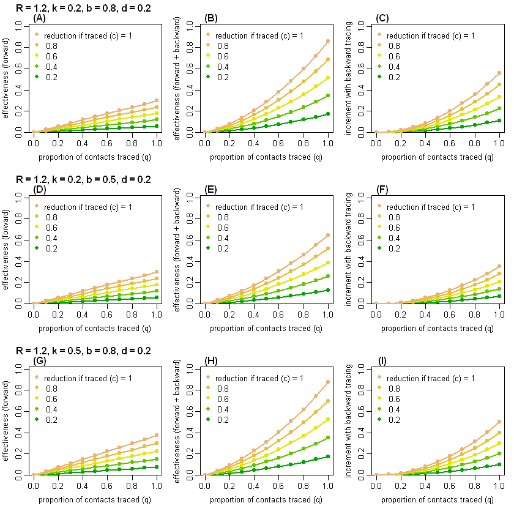

```r
par(mfrow=c(3,3),mar=c(4,3,2.5,1),mgp=c(2,0.6,0),las=0,yaxs="i")

tertiary<-plotbypc(R=1.2,k=0.2,b=0.8,d=0.2, panel=c("(A)","(B)","(C)"))
tertiary<-plotbypc(R=1.2,k=0.2,b=0.5,d=0.2, panel=c("(D)","(E)","(F)"))
tertiary<-plotbypc(R=1.2,k=0.5,b=0.8,d=0.2, panel=c("(G)","(H)","(I)"))
```

### Figure S1. The estimated effectiveness with $R = 2.5$.

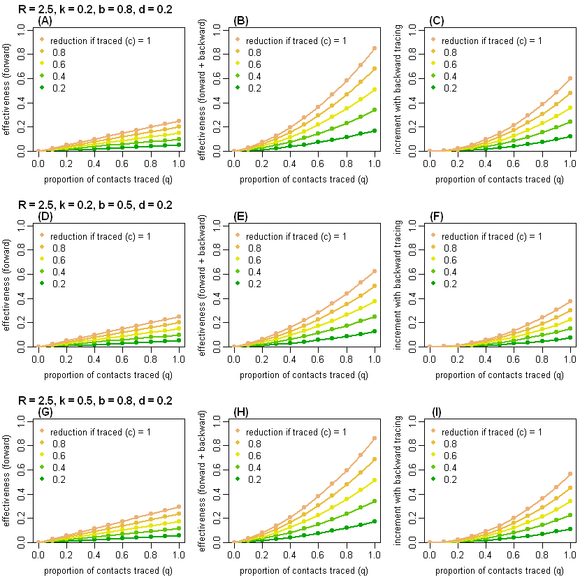

```r
par(mfrow=c(3,3),mar=c(4,3,2.5,1),mgp=c(2,0.6,0),las=0,yaxs="i")

tertiary<-plotbypc(R=2.5,k=0.2,b=0.8,d=0.2, panel=c("(A)","(B)","(C)"))
tertiary<-plotbypc(R=2.5,k=0.2,b=0.5,d=0.2, panel=c("(D)","(E)","(F)"))
tertiary<-plotbypc(R=2.5,k=0.5,b=0.8,d=0.2, panel=c("(G)","(H)","(I)"))
```

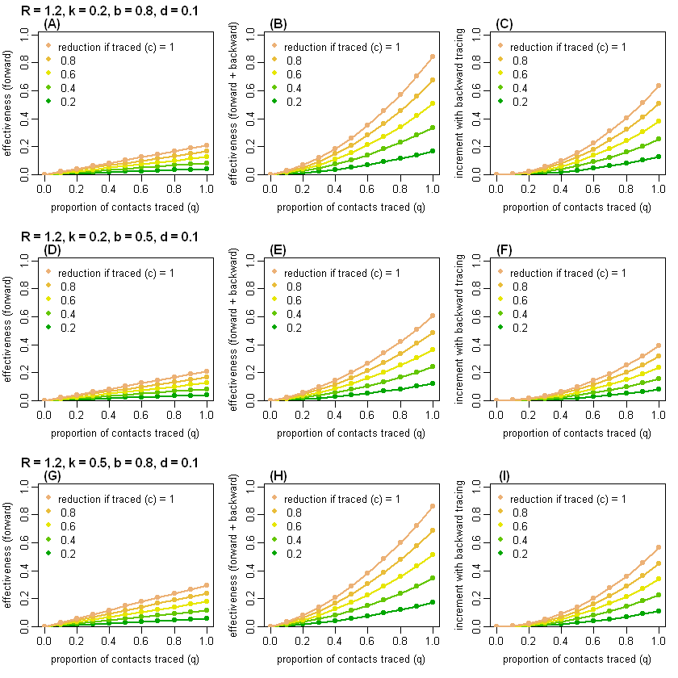

```r
par(mfrow=c(3,3),mar=c(4,3,2.5,1),mgp=c(2,0.6,0),las=0,yaxs="i")

tertiary<-plotbypc(R=1.2,k=0.2,b=0.8,d=0.1, panel=c("(A)","(B)","(C)"))
tertiary<-plotbypc(R=1.2,k=0.2,b=0.5,d=0.1, panel=c("(D)","(E)","(F)"))
tertiary<-plotbypc(R=1.2,k=0.5,b=0.8,d=0.1, panel=c("(G)","(H)","(I)"))
```

## The absolute number of cases averted by backward tracing

Figures show the estimated number of generation-3 cases averted by forward and backward contact tracing. Left panels (A, D, G): the number of cases averted by forward tracing alone; middle panels (B, E, H): the number of cases averted by a combination of forward and backward tracing; right panels (C, F, I): additional cases averted by combining backward tracing with forward tracing. Colours represent the assumed reproduction number ($R$).

### Figure 3 (main text). The number of generation 3 cases averted with 80% success rate of tracing and 80% relative reduction in transmission during quarantine.

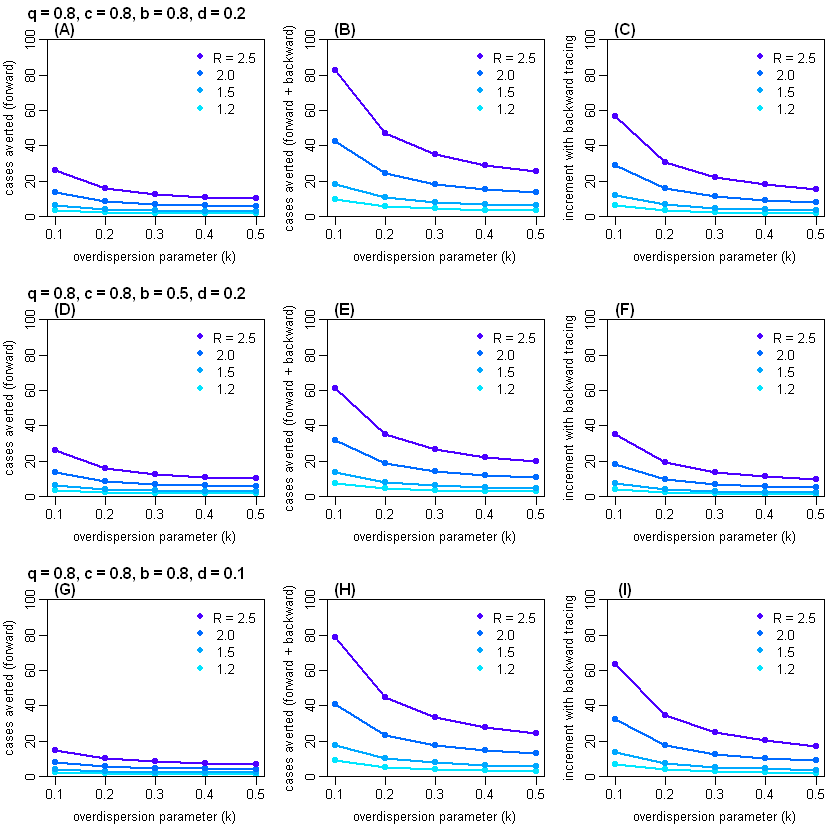

```r
par(mfrow=c(3,3),mar=c(4,3,2.5,1),mgp=c(2,0.6,0),las=0,yaxs="i")

tertiary<-plotbyRk(q=0.8,c=0.8,b=0.8,d=0.2, panel=c("(A)","(B)","(C)"), ylim=c(0,100))
tertiary<-plotbyRk(q=0.8,c=0.8,b=0.5,d=0.2, panel=c("(D)","(E)","(F)"), ylim=c(0,100))
tertiary<-plotbyRk(q=0.8,c=0.8,b=0.8,d=0.1, panel=c("(G)","(H)","(I)"), ylim=c(0,100))
```

### Figure S3. The number of generation 3 cases averted with 60% success rate of tracing and 60% relative reduction in transmission during quarantine.

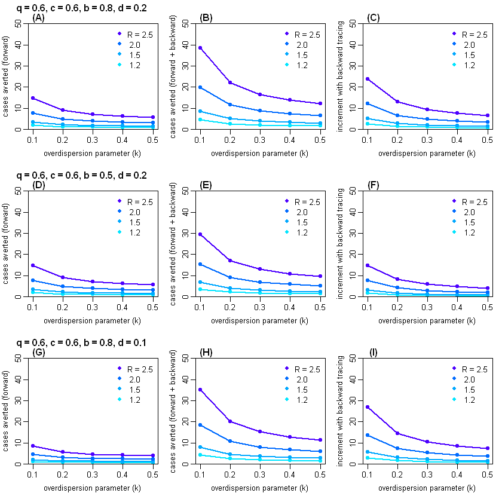

```r
par(mfrow=c(3,3),mar=c(4,3,2.5,1),mgp=c(2,0.6,0),las=0,yaxs="i")

tertiary<-plotbyRk(q=0.6,c=0.6,b=0.8,d=0.2, panel=c("(A)","(B)","(C)"), ylim=c(0,50))
tertiary<-plotbyRk(q=0.6,c=0.6,b=0.5,d=0.2, panel=c("(D)","(E)","(F)"), ylim=c(0,50))
tertiary<-plotbyRk(q=0.6,c=0.6,b=0.8,d=0.1, panel=c("(G)","(H)","(I)"), ylim=c(0,50))
```